# Part II - San Francisco Ford GoBike Services

## by Emmanuel Owoka

## Investigation Overview

> The goal of this investigation is for ford bike services to know how to improve their marketing strategies and where they should channel their insights by drawing insights from the following:
> 1. Count of trips based on hour of the day
> 2. Count of trips based on day of the week
> 3. Duration of trips based on Age of members
> 4. Count of trips based on user type

## Dataset Overview

> This dataset includes information about individual rides made in a bike-sharing system covering the greater San Francisco Bay area. This dataset includes information about individual rides made in a bike-sharing system covering the greater San Francisco Bay area.The Ford GoBike services is a bike sharing transportation provided by Ford that is easy to use, enjoyable and convenient. The dataset contains the 2019 for the month of February records which has 183,412 records and 16 features. I am going to be carrying out exploratory and explanatory data analysis on the dataset.

## Count of trips based on hour of the day

> It is observed that most trips are taken in the morning and in the afternoon than at night. This might mean that most riders prefer day rides to night rides, and most might have their engagements during the daytime.

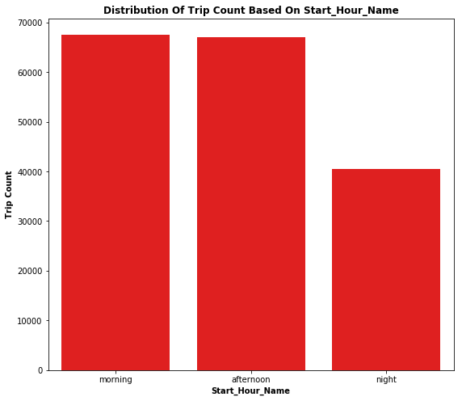

## Count of trips based on day of the week

> During the week, most trips are taken on Monday to Friday, with Thursday being the highest. There are less trips during the weekends

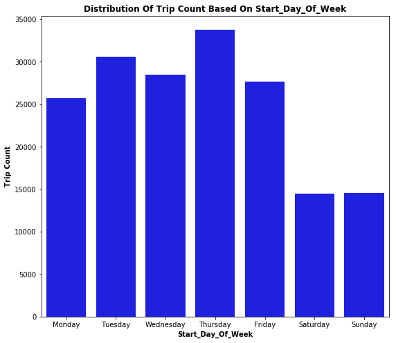

## Duration of trips based on Age of members

```
Text(0.5,1,'Duration of trips based on Age of members')
```

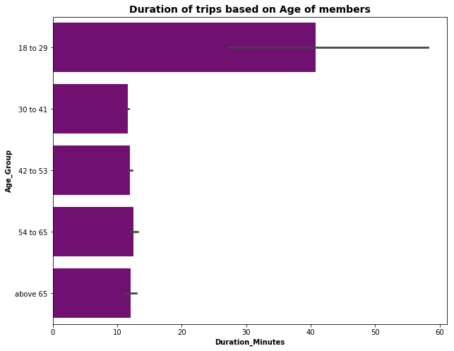

## Count of trips based on user type

> From the plot, subscribers go on trips more than customers. That means the bike services have more subscribers than customers, maybe the subscription price is reasonable enough and the customers might be tourists.

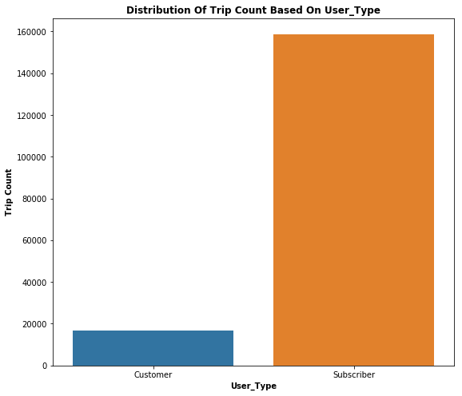